# Baseball Model: Winner After 5 Innings

jmc

First I will load in the data I have generated that has the following columns:  
“index” “index_x” “HomeTeam_x” “AwayTeam_x”  
“GameDate_x” “GameTime” “HomeOPS” “AwayOPS”  
“HomewRCPlus” “AwaywRCPlus” “HomePitcherName” “HomeERA”  
“HomePitcherGS” “AwayPitcherName” “AwayERA” “AwayPitcherGS”  
“HomeFIP” “AwayFIP” “HomexFIP” “AwayxFIP”  
“HomeScoreAfter5” “AwayScoreAfter5” “HomeTotalScore” “AwayTotalScore”  
“HomePlusDate” “index_y” “event_id” “GameDate_y”  
“GameTime_x” “HomeTeam_y” “OpeningHomeOdds” “HomeOdds”  
“OpeningHomeSpread” “HomeSpread” “GameTime_y” “AwayTeam_y”  
“OpeningAwayOdds” “AwayOdds” “OpeningAwaySpread” “AwaySpread”  
“OpeningHomeOddsSpreadRatio” “HomeOddsSpreadRatio” “OpeningAwayOddsSpreadRatio” “AwayOddsSpreadRatio”

There are a lot of variables I will not be using, so I am going to clean this up and compute three more columns:  
- resultAfter5: where 0 corresponds to a home loss after 5, 0.5 correponds to a tie after 5, and 1 corresponds to a home win.  
- homeFFImpliedProb: The implied probability given by the odds of the home team winning after 5.  
- awayFFImpliedProb: The implied probability given by the odds of the away team winning after 5.

All of the statistics are rolling 30 day team averages. Each batting stat is computed from the 30 day average of each batting lineup (all statistics from each player during the last 30 days are considered and used to compute statistics) as opposed to rolling team average.

All of these statistics were compiled using the Python Jupyter notebook included in this repository.

```r
data <- read.csv('adv_stats_plus_spreads_052119_thru_092919_corrected.csv',header=TRUE)
origdata <- read.csv('adv_stats_plus_spreads_052119_thru_092919_corrected.csv',header=TRUE)
data$resultAfter5[data$HomeScoreAfter5 > data$AwayScoreAfter5] <- 1
data$resultAfter5[data$HomeScoreAfter5 < data$AwayScoreAfter5] <- 0
data$resultAfter5[data$HomeScoreAfter5 == data$AwayScoreAfter5] <- 0.5


data$homeFFImpliedProb <- 1/data$HomeOdds
data$awayFFImpliedProb <- 1/data$AwayOdds
```

```r
predictors <- c("HomeOPS","AwayOPS","HomewRCPlus","AwaywRCPlus",
                "HomeERA","AwayERA","HomeFIP","AwayFIP","HomexFIP","AwayxFIP",
                "homeFFImpliedProb","awayFFImpliedProb","resultAfter5")

data <- data[data$HomePitcherGS > 4,]
data <- data[data$AwayPitcherGS > 4,]

data <- data[,predictors]
```

The next step is to divide the data into train and test sets. We will also be performing principcal component analysis on this data, and taking the top 8 principal components.

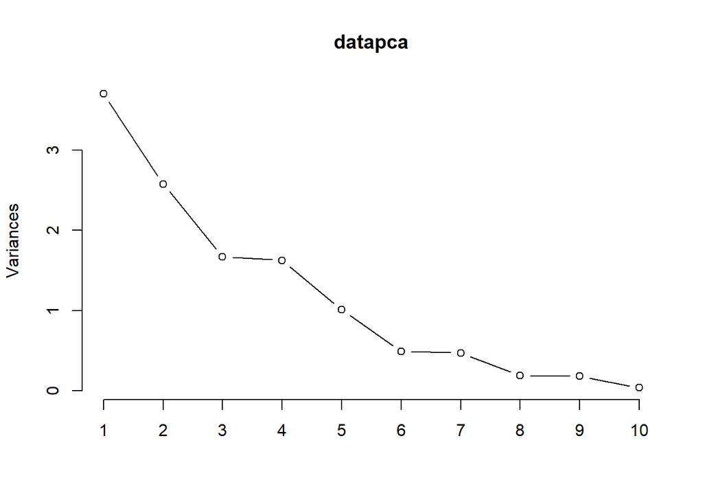

```r
scaled_data <- scale(data[,-13])
datapca <- prcomp(scaled_data)

screeplot(datapca,type="lines")
```

```r
set.seed(22)
idx <- sample(1:10,dim(data)[1],replace=TRUE)
pcdata4lm <- as.data.frame(cbind(datapca$x[,1:8],data[,13]))

scaleDataTest <- pcdata4lm[idx > 8,]
scaleDataTrain <- pcdata4lm[idx <= 8,]
dataTest <- data[idx > 8,]
dataTrain <- data[idx <= 8,]
```

```r
set.seed(22)


library(glmnet)
model <- cv.glmnet(as.matrix(scaleDataTrain[,-9]),
            as.matrix(scaleDataTrain[,9]),
            nfolds=10,
            standardize = TRUE)

summary(model)
```

```
##            Length Class  Mode
## lambda     65     -none- numeric
## cvm        65     -none- numeric
## cvsd       65     -none- numeric
## cvup       65     -none- numeric
## cvlo       65     -none- numeric
## nzero      65     -none- numeric
## call        5     -none- call
## name        1     -none- character
## glmnet.fit 12     elnet  list
## lambda.min  1     -none- numeric
## lambda.1se  1     -none- numeric
## index       2     -none- numeric
```

```r
pResultAfter5 <- predict(model, as.matrix(scaleDataTest[,-9]),s="lambda.min")
ResultAfter5 <- scaleDataTest[,9]
```

```r
newDataTest <- cbind(dataTest,pResultAfter5)
newDataTest$sub <- newDataTest$lambda.min - newDataTest$homeFFImpliedProb
newDataTest$EV_home <- (newDataTest$lambda.min * ((1/newDataTest$homeFFImpliedProb)*100)) - ((1-newDataTest$lambda.min)*100)
newDataTest$EV_away <- ((1-newDataTest$lambda.min) * ((1/newDataTest$awayFFImpliedProb)*100)) - ((1-(1-newDataTest$lambda.min))*100)
newDataTest$EV_diff <- newDataTest$EV_home - newDataTest$EV_away
```

Calculated above is the expected value for wagering on the home team or the away team. Below I will compute my bankroll starting with $1000 and $100 units and wagering on games that have an absolute value of expected value difference of 20 or greater. When the expected value difference is 40 or greater, I will use $200 as my units.

```r
# Initialize bankroll and unit size
bankroll <- 1000
games_wagered <- 0
# Loop through each row of the data table
for (i in 1:nrow(newDataTest)) {

  if (abs(newDataTest$EV_diff[i]) >= 20) {
    games_wagered <- games_wagered + 1

    unit_size <- 100

    if (abs(newDataTest$EV_diff[i]) >= 40){
      unit_size <- 200
    }


    if (newDataTest$EV_home[i] > newDataTest$EV_away[i]) {
      # Bet on home team
      if (newDataTest$resultAfter5[i] == 1) {
        # Home team won, add unit size to bankroll
        bankroll <- bankroll + (1 / newDataTest$homeFFImpliedProb[i] - 1) * unit_size
        # print('win')
      } else {
        # Home team lost, subtract unit size from bankroll
        bankroll <- bankroll - unit_size
        # print('loss')
      }
    } else {
      # Bet on away team
      if (newDataTest$resultAfter5[i] == 0) {
        bankroll <- bankroll + (1 / newDataTest$awayFFImpliedProb[i] - 1) * unit_size
        # print('win')
      } else {
        bankroll <- bankroll - unit_size
        # print('loss')
      }
    }
  }
}

# Print final bankroll
print(bankroll)
```

```
## [1] 1342
```

```r
print(games_wagered)
```

```
## [1] 72
```

Over 72 games that were wagered on, the model returns a profit of $342 when starting with a $1000 bankroll.

I have also included functions below that will be useful when presented with data that we need to fit into the framework of this model, i.e. using the variables needed in terms of the principal components that my model uses.

```r
descale_coefficients <- function (coeff, scale_params){
  # descale coefficients acquired from linear regression model
  dsc_coeff <- vector("numeric",length(coeff))
  for (i in 1:length(coeff)){
    dsc_coeff[i] <- (t_coeff[i]/scale_params$sd[i])
  }
  return(dsc_coeff)

}

pca2origcoeff <- function(pca_data, lm) {
  # transform pca coefficients back to scaled data coefficients
  t_coeff <- vector("numeric",dim(pca_data$rotation)[1])
  for (j in 1:dim(pca_data$rotation)[1]){
    for (k in 1:(length(lm$coefficients)-1)){
      t_coeff[j] <- t_coeff[j] + (lm$coefficients[k+1]*pca_data$rotation[j,k])
    }

  }
  return(t_coeff)
}

jscale <- function(df){

  scaler <- list()

  scaler$center <- colMeans(df)
  scaler$sd <- numeric(ncol(df))

  for (i in 1:dim(df)[2]){
    scaler$sd[i] <- sd(df[,i])

  }

  names(scaler$sd) <- colnames(df)


  return(scaler)

}
```